# Getting started with `hclust1d`

Szymon Nowakowski

# This document

The purpose of this vignette is to introduce readers to `hclust1d` package, and bring them up to speed by providing a simple use case example.

# Clustering in 1D

The name of `hclust1d` package stands for Hierarchical CLUSTering for 1D. 1D means that data is univariate or one dimensional, i.e. constitutes of real numbers. The package contains a suit of algorithms for univariate agglomerative hierarchical clustering. Clusters or clustering process in 1D is also called **segmentation** or **breaks** [Fisher, 1958 and Jenks, 1977] and arises naturally in [research related to choropleth maps](https://macwright.com/2013/02/18/literate-jenks.html).

# Hierarchical clustering in a nutshell

Agglomerative hierarchical clustering first assigns each observation (1D point in our case) to a singleton cluster. Thus, we start off with as many clusters as there are observations. Then, in each step of the algorithm, the closest two clusters get merged. In order to decide, which clusters are *closest*, we need a way to measure either a distance, a dissimilarity or a similarity between clusters.

Below, for clarity, we will drop saying *a distance, or a dissimilarity, or a similarity* and will refer to *a distance* in this broader colloquial sense, in which for instance a triangle inequality may not hold.

### Linkage function concept

Please note, that we start off with a measure of distance, but it works for observations only. So we need to generalize this initial measure to work for clusters, too. It is easy for singleton clusters - we simply say, that a distance (or a dissimilarity, or a similarity) between two singleton clusters is the same as between the two observations involved.

But in order to say what is a distance between more complex clusters, we need a concept of a *linkage function*. This concept constitutes a link between the distance for clusters and the distance between observations, hence its name.

For instance, we could say that a distance between two clusters $A$ and $B$ is the same as the minimal distance between any observation $a \in A$ and any observation $b \in B$. This would be called a *single linkage* in hierarchical clustering terminology.

Sometimes, instead of defining a cluster-wise distance in terms of distances between the clustered observations, it would be easier to build a distance concept for any two clusters (that are present in a current step of our hierarchical clustering procedure) inductively upon the distance concept as it got defined for smaller clusters. Observe, that we have it defined for singleton clusters already. Then, we could say, for instance, that after $A$ and $B$ got merged (denoted $A \cup B$) the distance between $A \cup B$ and any other cluster $C$ is the arithmetic average between two distances: the one between $A$ and $C$ and the one between $B$ and $C$. This would be called a *mcquitty* or *WPGMA linkage* clustering.

### Merging height

Now, that we understand a concept of a linkage function, the concept of closest clusters becomes clear, too. After the closest clusters get merged, the *height* of this merging is defined as their cluster-wise distance. Obviously not only the choice of the closest clusters, but also the merging height, they both depend on a choice of a linkage function.

`hclust1d` supports a comprehensive list of choices of a linkage function, matching all possible choices in `stats::hclust` with an addition of a `true_median` linkage.

### Linkage functions list

Below find a complete list of all linkage functions supported by `hclust1d`. We also state what is a distance of the newly merged cluster $A \cup B$ and some other cluster $C$. Sometimes it can be done in terms of the observations involved, and sometimes an inductive definition is easier. Below, the distance function is denoted $d(\cdot, \cdot)$ and it works for observations, and with a slight abuse of notation for clusters or for arbitrary points; the number of observations in a cluster $X$ is denoted $\left | X \right |$.

- `complete`: a distance between two clusters is the maximum distance between all pairs of observations in the involved clusters, formally $d(A \cup B, C) = \max_{x \in A \cup B,\,y \in C}d(x,y)$.
- `single`: a distance between two clusters is the minimum distance between all pairs of observations in the involved clusters, formally $d(A \cup B, C) = \min_{x \in A \cup B,\,y \in C}d(x,y)$.
- `average`, called also UPGMA (Unweighted Pair Group Method with Arithmetic mean): a distance between two clusters is the (arithmetic) average distance between all pairs of observations in the involved clusters, formally $d(A \cup B, C) = \frac{\sum_{x \in A \cup B} \sum_{y \in C} d(x,y)}{\left | A \cup B \right | \cdot \left | C \right |}$.
- `centroid`, called also UPGMC (Unweighted Pair Group Method with Centroid average): $d(A \cup B, C) = \left \| \frac{ \sum_{x \in A \cup B} x }{\left | A \cup B \right |} - \frac{ \sum_{y \in C} y }{\left | C \right |} \right \| ^2$. Observe, that *centroid* linkage reports height as the **squared** euclidean distance between clusters’ centroids. With $d(\cdot, \cdot)$ being an euclidean distance, this can be rewritten as $d(A \cup B, C) = d \left( \frac{ \sum_{x \in A \cup B} x}{\left | A \cup B \right |}, \frac{ \sum_{y \in C} y}{\left | C \right |} \right ) ^2$.
- `median`, called also WPGMC (Weighted Pair Group Method with Centroid average): $d(A \cup B, C) = d(m_{A \cup B}, m_C)^2$ with $m_X$ equal to the observation in cases of $X$ being a singleton, and $m_{A \cup B} = \frac{1}{2}\left (m_A + m_B \right )$ for merged clusters $A$ and $B$. Observe, that *median* linkage reports height as the **squared** distance, similarly to *centroid* linkage. Observe also, that this definition is in odds with the [Wikipedia hierarchical clustering page](https://en.wikipedia.org/wiki/Hierarchical_clustering#Cluster_Linkage), and although it is compatible with `stats::hclust`, this behavior is not well documented in `stats::hclust`, either.
- `mcquitty`, called also WPGMA (Weighted Pair Group Method with Arithmetic mean): $d(A \cup B, C) = \frac{d(A, C) + d(B, C)}{2}$
- `ward.D`, called also MISSQ (Minimum Increase of Sum of SQuares): $d(A \cup B, C) = 2 \cdot \frac{\left | A \cup B \right | \cdot \left | C \right |}{\left | A \cup B \cup C \right |} \cdot \left \| \frac{ \sum_{x \in A \cup B} x}{\left | A \cup B \right |} - \frac{ \sum_{y \in C} y}{\left | C \right |} \right \| ^2$. Observe, that *ward.D* linkage reports height as the **squared** euclidean distance between clusters’ centroids weighted with a harmonic mean of relevant clusters’ sizes. This definition is in odds with what one can read in the [Wikipedia hierarchical clustering page](https://en.wikipedia.org/wiki/Hierarchical_clustering#Cluster_Linkage). With $d(\cdot, \cdot)$ being an euclidean distance, this can be rewritten as $d(A \cup B, C) = 2 \cdot \frac{\left | A \cup B \right | \cdot \left | C \right |}{\left | A \cup B \cup C \right |} \cdot d \left( \frac{ \sum_{x \in A \cup B} x}{\left | A \cup B \right |}, \frac{ \sum_{y \in C} y}{\left | C \right |} \right ) ^2$.
- `ward.D2`: added to `stats::hclust` in `R >3.0.3` versions to implement the original *Ward’s* linkage function [Murtagh and Legendre, 2014] which is *not* implemented with `ward.D`. The reported height in `ward.D2` is the square root of the height in `ward.D`, i.e. $d(A \cup B, C) = \sqrt{ 2 \cdot \frac{\left | A \cup B \right | \cdot \left | C \right |}{\left | A \cup B \cup C \right |} } \cdot \left \| \frac{ \sum_{x \in A \cup B} x}{\left | A \cup B \right |} - \frac{ \sum_{y \in C} y}{\left | C \right |} \right \|$. So *ward.D2* linkage reports height as the **unsquared** euclidean distance between clusters’ centroids weighted with a square root of harmonic mean of relevant clusters’ sizes. With $d(\cdot, \cdot)$ being an euclidean distance, this can be rewritten as $d(A \cup B, C) = \sqrt{2 \cdot \frac{\left | A \cup B \right | \cdot \left | C \right |}{\left | A \cup B \cup C \right |} } \cdot d \left( \frac{ \sum_{x \in A \cup B} x }{\left | A \cup B \right |}, \frac{ \sum_{y \in C} y }{\left | C \right |} \right )$.
- `true_median`: $d(A \cup B, C) = d(m_{A \cup B}, m_C)$ with $m_X$ being the median of observations in $X$ (specifically, the middle-valued observation in case of $\left | X \right |$ odd, and the arithmetic mean of the two middle-valued observations in case of $\left | X \right |$ even). Note also, that a concept of a median makes sense only for 1D points.

### Computational complexity of 1D hierarchical clustering

Hierarchical clustering in the 1D setting has time complexity of $\mathcal{O}(n\log n)$ time regardless of the linkage function used.

Compatibility with `stats::hclust` was high in the priority list and thus for 1D data it is simply a matter of a plug-and-play replacement of `stats::hclust` calls to be able to use the advantage of our fast implementation of this asymptotically much more efficient algorithm. The how-to is covered in detail in our [replacing `stats::hclust` vignette](https://cran.r-project.org/package=hclust1d/vignettes/replacing-hclust.html).

# OK, so let’s get started

To load the package into memory execute the following line:

```r
library(hclust1d)
```

We will work with random normally distributed data points in this vignette.

```r
points <- rnorm(10)
```

Working with `hclust1d` is very simple an requires only passing the data points vector and optionally a linkage method to `hclust1d` function (complete linkage is used as a default, if the linkage method is not provided). The simplest example of a complete linkage clustering:

```r
result <- hclust1d(points)
```

The `hclust1d` function returns an object of the same type that is returned from `stats::hclust` (a list object with S3 class , to be specific).

- This makes it straightforward to further work with the clustering results. E.g. we can plot it (observe that `plot.hclust` gets called internally below):

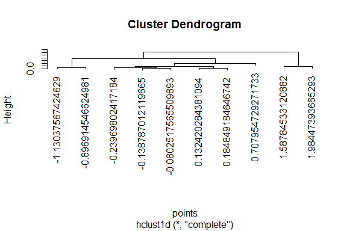

  ```r
  plot(result)
  ```

- We can also generate clustering for the named 1D points:

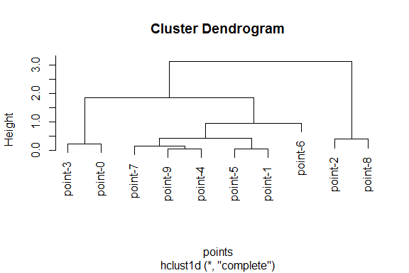

  ```r
  names(points) <- paste("point", 0:9, sep = "-")
  result <- hclust1d(points)
  plot(result)
  ```

- We can print the clustering result:

  ```r
  print(result)
  ```

  ```
  #>
  #> Call:
  #> hclust1d(x = points)
  #>
  #> Cluster method   : complete
  #> Distance         : euclidean
  #> Number of objects: 10
  ```

- Or we can convert the clustering result to a dendrogram and further work with it (observe that `plot.dendrogram` gets called internally below):

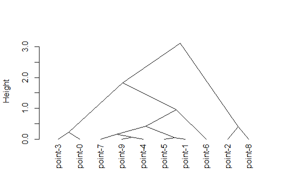

  ```r
  dendrogram <- as.dendrogram(result)
  plot(dendrogram, type = "triangle", ylab = "Height")
  ```

- Or we can use any other specialized packages, like `ggdendro` with `ggplot2` or `ape` packages, to further visualize and work with the result.

# How to change the linkage function used for clustering

By default, `complete` linkage is used for clustering. But it is very straightforward to explicitly say which linkage function is to be used. You just need to specify a `method` argument of the `hclust1d call`, as in example below with `mcquitty` linkage function. Observe that the linkage function name is passed as a character string:

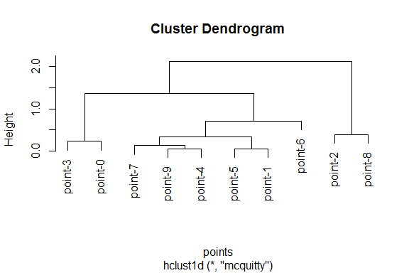

```r
result <- hclust1d(points, method = "mcquitty")
plot(result)
```

# Should I provide points or rather a distance matrix to `hclust1d`?

In a default statistical package in `R`, `stats::hclust` requires that the `dist` structure is provided for clustering. In fact, `stats::hclust` cannot be executed on raw $\mathbb{R}^d$ points.

However, `hclust1d` is more flexible in this regard. It accepts both $\mathbb{R}^d$ points as input (with $d=1$, because `hclust1d` works only in 1D setting) and a `dist` S3 class input. Actually, the raw points are recreated from a distance structure anyway, so raw point input is preferred and works a little bit faster.

If you want to provide the `dist` structure, please remember to change a `distance` argument to `TRUE` in a call to `hclust1d`. The two examples below return results that are equivalent (but not equal - a note on that follows below).

### Examples

For diversity, `single` linkage is used in the two examples below:

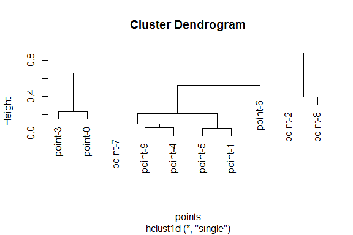

```r
result_points <- hclust1d(points, method = "single")
plot(result_points)
```

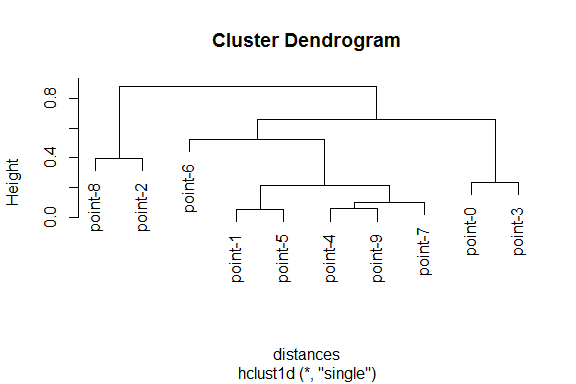

```r
distances <- dist(points)

result_dist <- hclust1d(distances, distance = TRUE, method = "single")
plot(result_dist)
```

But are the results the same? On a close inspection, you’ll notice that the resulting clusterings are mirror reflections of each other. It is perfectly OK, the distance structure specifies the mutual distances, but not the order or shift of points, so the resulting clusterings are equivalent up to the order and shift.

# What about squared distances?

In a default statistical package in `R`, `stats::hclust` requires that the **squared** `dist` structure is provided for `ward.D`, `centroid` and `median` linkage functions. It is also reflected in merging height resulting in those linkages: the height is returned as the appropriate distance measure, **squared**.

Again, `hclust1d` is more flexible in this regard. It accepts both squared and unsquared distances (squared or unsquared `dist` S3 class input), and it even accepts raw $\mathbb{R}^d$ points as input (with $d=1$, because `hclust1d` works only in 1D setting). Actually, the raw points are preferred in this setting, too.

The below points should be observed:

- If you want to provide the **unsquared** `dist` structure, please remember to change a `distance` argument to `TRUE` in a call to `hclust1d`.
- If you want to provide the **squared** `dist` structure, please remember to change both `distance` and `squared` arguments to `TRUE` in a call to `hclust1d`.

### Examples

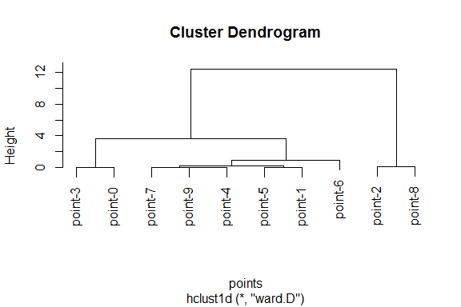

```r
result_points <- hclust1d(points, method = "ward.D")
plot(result_points)
```

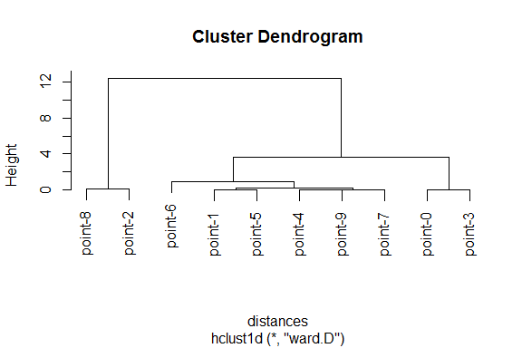

```r
distances <- dist(points)

result_dist <- hclust1d(distances, distance = TRUE, method = "ward.D")
plot(result_dist)
```

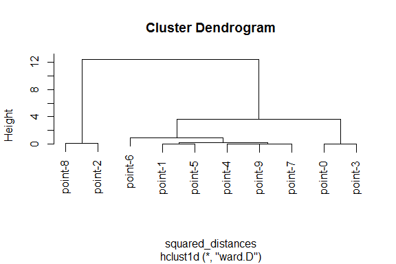

```r
squared_distances <- distances ^ 2

result_dist <- hclust1d(squared_distances, distance = TRUE, squared = TRUE, method = "ward.D")
plot(result_dist)
```

The three examples above return results that are equivalent (up to the order and shift, because again you will notice, that the first clustering is a mirror reflection of the second and the third clusterings).

Please also note, that regardless of input, the height is returned as the appropriately **squared** distance measure for `ward.D`, `centroid` and `median` linkage functions, so the results remain compatible with `stats::hclust` results for the squared `dist` input (for those linkages). Please check the result below, for comparison. It presents the same clustering with the same heights, only the presented order of points is reorganized.

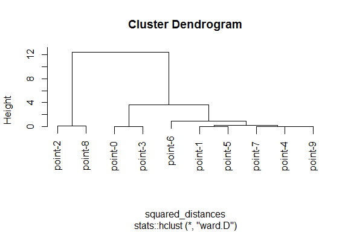

```r
result_dist_stats_hclust <- stats::hclust(squared_distances, method = "ward.D")
plot(result_dist_stats_hclust)
```

### A note on `ward.D2` and `ward.D`

There is a lot of confusion on `ward.D` and `ward.D2` linkages on Internet. Maybe not so surprisingly, the difference is very simple: the returned merging heights in `ward.D` are squared, while in `ward.D2` they are not. You can see it by comparing the following output:

```r
distances <- dist(points)

result_ward.D <- hclust1d(distances, distance = TRUE, method = "ward.D")
result_ward.D2 <- hclust1d(distances, distance = TRUE, method = "ward.D2")

print(result_ward.D$height)
```

```
#> [1]  0.002748790  0.003426376  0.022595304  0.054504098  0.157314251
#> [6]  0.232947678  0.903435672  3.683388750 12.403250822
```

```r
print(result_ward.D2$height ^ 2)
```

```
#> [1]  0.002748790  0.003426376  0.022595304  0.054504098  0.157314251
#> [6]  0.232947678  0.903435672  3.683388750 12.403250822
```

Unfortunately, `stats::hclust` adds another layer of confusion, by requiring implicitly that the input is provided as *squared* distances for `ward.D` and *unsquared* for `ward.D2`. Let’s try to recreate the above outputs by using `stats::hclust`:

```r
distances <- dist(points)
squared_distances <- distances ^ 2

result_ward.D_stats_hclust <- stats::hclust(squared_distances, method = "ward.D")
result_ward.D2_stats_hclust <- stats::hclust(distances, method = "ward.D2")

print(result_ward.D_stats_hclust$height)
```

```
#> [1]  0.002748790  0.003426376  0.022595304  0.054504098  0.157314251
#> [6]  0.232947678  0.903435672  3.683388750 12.403250822
```

```r
print(result_ward.D2_stats_hclust$height ^ 2)
```

```
#> [1]  0.002748790  0.003426376  0.022595304  0.054504098  0.157314251
#> [6]  0.232947678  0.903435672  3.683388750 12.403250822
```

The distinction that `stats::hclust` makes about its input (squared or unsquared) is unfortunately implicit, not explicit.

# Cutting heights

The last topic presented in this introductory vignette is how to get an actual single clustering from the dendrogram. You’ll notice, that a dendrogram in hierarchical clustering contains multiple clusterings: there is a clustering into one cluster only, there is a clustering into two clusters and ultimately, there is a clustering into as many clusters as there are observations. The number of actual clusters in a clustering depends on a *height* that a dendrogram tree is cut.

We will use a standard `stats::cutree` function to cut the results of `hclust1d`, because those results are fully compatible with the results of `stats::hclust`. One can cut a dendrogram either at a given height, or specifying a desired number of clusters.

But before we get into cutting, let’s first examine a `complete` linkage clustering full dendrogram:

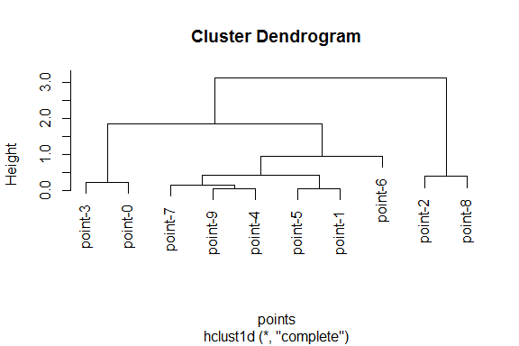

```r
result <- hclust1d(points)
plot(result)
```

The exact merging height values may not be apparent from the dendrogram plot. They are as follows:

```r
print(result$height)
```

```
#> [1] 0.05242890 0.05853526 0.15944627 0.23346113 0.39662861 0.42454721 0.94765275
#> [8] 1.83833040 3.11484961
```

The closest points are `point-1` and `point-5` with a distance of 0.0524289 and thus merged at the first height (valued 0.0524289). So if you cut the dendrogram at 0.0524289 you’ll get $n-1$ clusters, with $n$ equal to the number of points, $n=10$ in this example.

```r
n_minus_one_clusters <- stats::cutree(result, h = result$height[1])
print(n_minus_one_clusters)
```

```
#> point-0 point-1 point-2 point-3 point-4 point-5 point-6 point-7 point-8 point-9
#>       1       2       3       4       5       2       6       7       8       9
```

In this example you can see how the clusters get assigned: each point in a vector gets assigned a cluster number, with both `point-1` and `point-5` being assigned to the same cluster number 2, and all other points having their own singleton cluster.

There are $n-1$ merging heights for $n$ points, in our case there are 9 heights. At the last 9-th height, valued 3.1148496, the last two clusters get merged and we have only one cluster at that height:

```r
one_cluster <- stats::cutree(result, h = result$height[9])
print(one_cluster)
```

```
#> point-0 point-1 point-2 point-3 point-4 point-5 point-6 point-7 point-8 point-9
#>       1       1       1       1       1       1       1       1       1       1
```

Let’s say our goal is to get 3 clusters. We should cut the dendrogram at any height between the 7-th height 0.9476528 (inclusive) and the 8-th height 1.8383304 (exclusive). Let’s cut the dendrogram at the height 1.0:

```r
three_clusters <- stats::cutree(result, h = 1.0)
print(three_clusters)
```

```
#> point-0 point-1 point-2 point-3 point-4 point-5 point-6 point-7 point-8 point-9
#>       1       2       3       1       2       2       2       2       3       2
```

Alternatively, one can cut the dendrogram specifying not the cutting height, but rather explicitly the desired number of clusters. You can specify the desired number of clusters with a `k` argument to `cutree`:

```r
alt_three_clusters <- stats::cutree(result, k = 3)
print(alt_three_clusters)
```

```
#> point-0 point-1 point-2 point-3 point-4 point-5 point-6 point-7 point-8 point-9
#>       1       2       3       1       2       2       2       2       3       2
```

How to read the clustering resulting from this cut? As we said earlier, each point gets assigned a cluster number, so in this last example we get the following clustering (into three clusters):

- the first cluster with 2 points: `point-0` and `point-3`,
- the second cluster with 6 points: `point-1`, `point-4`, `point-5`, `point-6`, `point-7` and `point-9`,
- the third cluster with 2 points: `point-2` and `point-8`.

Have a look at the dendrogram plot above to verify that indeed a cut at the height 1.0, or (equivalently) into 3 clusters, would result in this clustering structure.

# References

1. Fisher, W. D. 1958. On Grouping for Maximum Homogeneity. J. Am. Stat. Assoc. 53 (284): 789–98. doi:10.2307/2281952
2. Jenks, G. F. 1977. Optimal Data Classification for Choropleth Maps. University of Kansas. Department of Geography.
3. Murtagh, F. and Legendre, P. 2014. Ward’s hierarchical agglomerative clustering method: which algorithms implement Ward’s criterion? *Journal of Classification*, **31**, 274–295. doi:10.1007/s00357-014-9161-z